# Bayesian Statistics

25th April, 2017

## Motivation

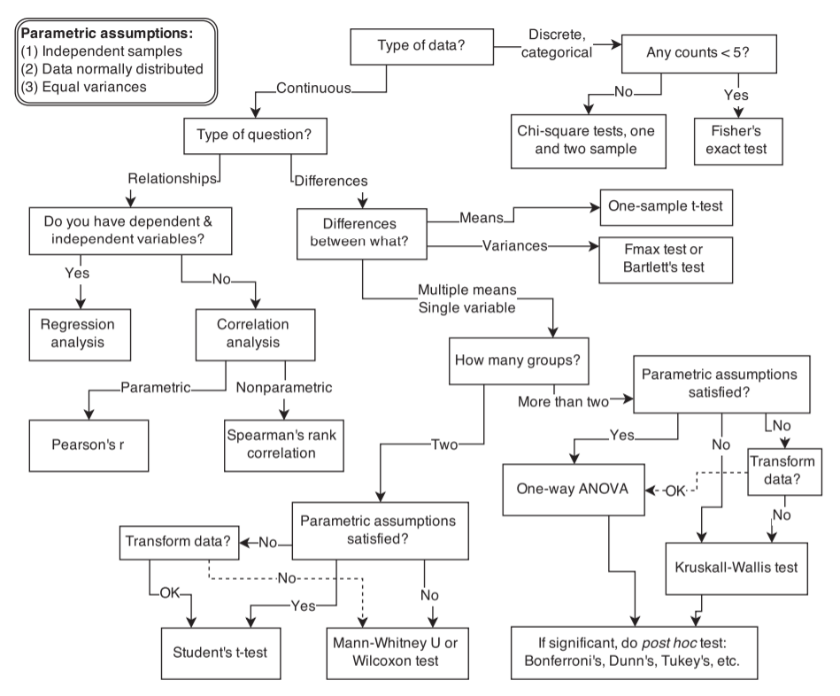

## Learning outcomes

- **Oblique**
  - Get a feeling for *statistical modeling*
  - Get a feeling for statistics as a (young) discipline
- **Concrete**
  - Be able to state the differences between classical and Bayesian statistics
  - Be able to apply simple Bayesian models to your data
- **Wishful**
  - Become hungry for statistical developments
  - Read the linked resources at https://github.com/fdabl/Intro-Stats to dive deeper

## Outline

- **1a.** History of statistics
  - Controversies and enigmatic key players
  - The superego, ego, and the id in statistical reasoning
- **1b.** Introduction to probability
  - Why most published research is false
  - Do I have testicular cancer?
  - Frequentist versus Bayesian interpretation of probability
- **2.** Foundation: Statistical models
  - Bread and butter example
  - Likelihoods, law of large number, central limit theorem
- **3.** Classical statistics
  - Maximum likelihood, sampling distributions, bootstrapping
  - Confidence intervals, \(p\)-values

## Outline

- **4.** Introduction to Bayesian statistics
  - Parameter estimation
  - Model comparison
  - Model prediction
- **5.** Some applications of Bayesian principles
  - Simulator sickness and age
  - Harry Potter and Personality
  - Markov chain Monte Carlo with People
- **6.** Practical examples using JASP
  - Is height associated with being president?
  - *~ ~ tralala ~ ~ … Wish we could turn back time .. ~ ~ tralala ~ ~*
- **7.** Final thoughts and further resources

## History of statistics

## Overview

- Before 1940, significance testing was virtually non-existant
- By 1955, 80% of empirical articles reported significance tests
- Today, the figure is close to 100% (see Gigerenzer, 1993)

"[Statisticians] have already overrun every branch of science with a rapidity of conquest rivalled only by Atilla, Mohammed, and the Colorado beetle."

- Kendall (1942, p.69)

## History

- Fienberg (1992) identifies four periods:
- **1660 - 1750**: Pascal, Fermat, Bernoulli, De Moivre
- **1750 - 1820**: Bayes, Laplace, Legendre, Gauss
- **1820 - 1900**: Quetelet, Galton, Edgeworth, Yule, K. Pearson
- **1900 - 1950**: Gosset, Fisher, Neyman, E. Pearson, Ramsey, Kolmogorov, de Finetti, Jeffreys, Wald, Savage

## Ronald Fisher

[figure not shown]

- Father of modern statistical inference
- Randomization, design of experiments
- \(p\)-value, \(\alpha\) level, null hypothesis, analysis of variance
- Maximum likelihood, sufficient statistics
- Parametric modeling, distributional theory
- Founder of population genetics
- Sexy son hypothesis

## Fisher's approach to testing

1. Setup a null hypothesis.
2. Report the exact level of significance (e.g., \(p = .051\) or \(p = .049\)). Do not use a conventional 5% level, and do not talk about accepting or rejecting hypotheses.
3. Use this procedure only if you know very little about the problem at hand

## Ronald Fisher: Evidential statistics

"… no scientific worker has a fixed level of significance at which from year to year, and in all circumstances, he rejects hypotheses; he rather gives his mind to each particular case in the light of his evidence and his ideas."

- Sir Ronald A. Fisher (1956)

## Neyman-Pearson

- Jerzy Neyman (1894 - 1981) was a polish man who did much of his work in the United States
- Egon Pearson (1895 - 1980) was the son of the eminent Karl Pearson
- Together, they put Fisher's ideas on a rigorous mathematical basis
- Fisher didn't like it, and a personal feud began that lasted until his death
- Some concepts they introduced were
  - The alternative hypothesis
  - Type I (\(\alpha\)) and Type II (\(\beta\)) errors
  - Statistical power
  - Confidence intervals
  - Decision theoretic foundation of hypothesis testing

## Neyman-Pearson's approach to testing

1. Setup two statistical hypotheses, \(H_1\) and \(H_2\), and decide about \(\alpha\), \(\beta\), and sample size before the experiment, based on subjective cost-benefit considerations. These define a rejection region for each hypothesis.
2. If the data falls into the rejection region of \(H_1\), accept \(H_2\); otherwise accept \(H_1\). Note that accepting a hypothesis does not mean that you believe in it, but only that you act is if it were true. Report only \(p < \alpha\) or \(p \geq \alpha\).
3. The usefulness of the procedure is limited among others to situations where you have a disjunction of hypotheses (e.g., either \(\mu_1 = 8\) or \(\mu_2 = 10\) is true) and where you can make meaningful cost-benefit trade-offs for choosing \(\alpha\) and \(\beta\).

## Neyman-Pearson: Behavioural statistics

"We are inclined to think that as far as a particular hypothesis is concerned, no test based upon the theory of probability can by itself provide any valuable evidence of the truth or falsehood of that hypothesis. But we may look at the purpose of tests from another viewpoint. Without hoping to know whether each separate hypothesis is true or false, we may search for rules to govern our behaviour with regard to them, in following which we insure that, in the long run of experience, we shall not be too often wrong".

- Jerzy Neyman & Egon Pearson (1933, pp. 290-291, as quoted in Johansson, 2011)

## Current statistical practice

- Is a hybrid between the approaches of Fisher and Neyman-Pearson
- Gigerenzer (2004) introduces the term ''null ritual'' to specify current practices

```
1) Setup a statistical null hypothesis, but do not specifiy your own hypothesis nor any alternative
2) use the 5% significance level for rejecting the null and accepting your hypothesis
3) always perform this procedure
```

## Bayes-Laplace-Jeffreys

- Thomas Bayes (1701 - 1761) was a Presbyterian minister whose "An essay towards solving a Problem in the Doctrine of Chances" used inverse probability — Bayes' rule
- Pierre-Simon Laplace was "the Newton of France"
  - Among many other things, generalized Bayes' rule and proved the central limit theorem
- Harold Jeffreys (1891 - 1989) revived the Bayesian view of probability
  - Developed the Bayes factor, default Bayesian tests, and Jeffreys priors
- Use Bayes' rule to make uncertainty statements about parameters, models, and hypotheses
- (This is not possible in any other statistical approach)

## Jeffreys' approach to testing

- Jeffreys had four convictions
  - Inference is inductive
  - Induction requires a logic of partial belief
  - The test of a general law requires it be given a prior probability
  - Classical tests are inadequate
- (For an excellent account, see Ly, Verhagen, Wagenmakers, 2016)

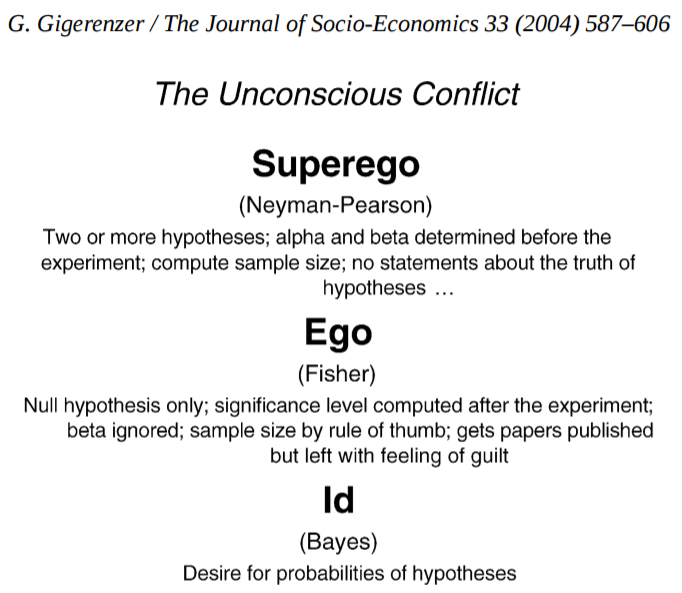

## Introduction to Probability

## Probability theory

- Is based on set theory (Kolmogorov, 1933)
- \(\mathcal{S} = \{0, 1, 2, 3\}\) denotes the *sample space*
- \(\mathcal{A} = \{0, 1\}\) and \(\mathcal{B} = \{1, 2\}\) denote events; \(\mathcal{A}, \mathcal{B} \subset \mathcal{S}\)

\[ \begin{align*} \mathcal{A^c} &= \{2, 3\} \\ \mathcal{B^c} &= \{0, 3\} \\ \mathcal{A} \cap \mathcal{B} &= \{1\} \\ \mathcal{A} \cup \mathcal{B} &= \{0, 1, 2\} \end{align*} \]

## Naive definition

- Naive view assumes equally likely outcomes, resulting in

\[ P(A) = \frac{|A|}{|S|} \]

- where \(P(.)\) is a function that takes a set and returns a real number on the interval [0, 1]
- In order to be a valid probability function, the function must satisfy certain constraints

## Non-naive definition

- Kolmogorov's axioms (1933)

\[ \begin{align*} &P(\mathcal{S}) = 1, \, P(\emptyset) = 0 \\ &P(\bigcup^{\infty}_{i = 1}\mathcal{A}_i) = \sum^{\infty}_{i=1}P(\mathcal{A}_i) \qquad A_1, A_2, \ldots \text{are disjoint} \end{align*} \]

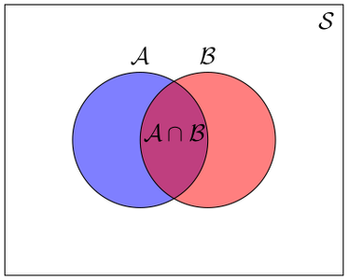

## Non-naive definition

- Some neat properties result

\[ \begin{split} P(\mathcal{A}^c) &= 1 - P(\mathcal{A}^c) \\ P(\mathcal{A \cup B}) &= P(\mathcal{A}) + P(\mathcal{B}) - P(\mathcal{A \cap B}) \\ P(\mathcal{A}) &\leq P(\mathcal{B}) \, \, \, \, \, \, \, \text{ if } \mathcal{A} \subseteq \mathcal{B} \end{split} \]

## How likely is today somebody's birthday?

- There are \(k = 35\) people in the room
- We assume that no people share birthdays, i.e., sampling without replacement (\(k \leq 365\))
- Then

\[ P(\text{somebody's birthday}) = k \cdot \frac{1}{365} \]

```r
k <- 35
S <- seq(365)
today <- 31 + 28 + 31 + 25

mean(
  replicate(100000, any(sample(S, k, replace = FALSE) == today))
)
```

```
## [1] 0.09602
```

## How likely is today somebody's birthday?

- Used the law of large numbers to approximate the result (more later)
- But clearly our assumption that people don't share birthdays is wrong
- How likely is it that at least two people share birthdays?
- Use \(P(A^c) = 1 - P(A)\) to simplify the problem

## Birthday Problem

\[ \begin{split} P(\text{two or more people share birthdays}) &= 1 - P(\text{nobody shares birthdays}) \\[1ex] &= 1 - \frac{365 \cdot (365 - 1) \cdot \ldots \cdot (365 - k + 1)}{365^k} \end{split} \]

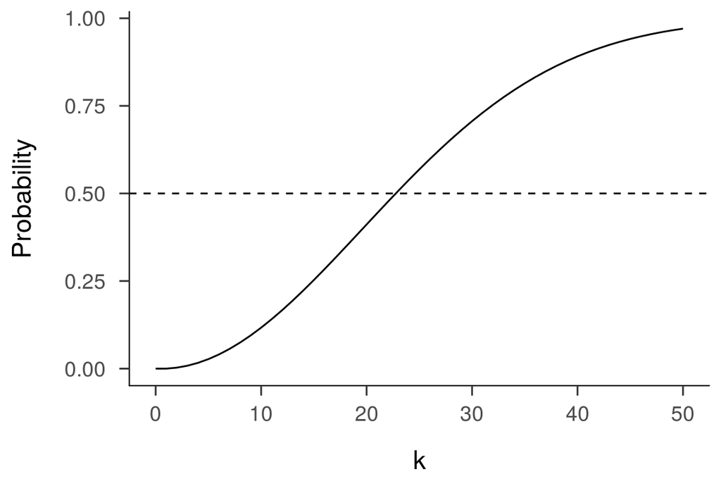

## A murder mistery

- A scream wakes you
- You run in the kitchen and see a dead body — who killed your husband?
- There are three possible perpetrators
  - Your husband himself
  - The person he had an affair with
  - The butler
- There are three possible murder weapons
  - An axe
  - A knife
  - A pistol
- How should you proceed?
- Instinctively, you sketch a probability table

## A murder mistery

|  | \(\text{He killed himself}\) | \(\text{She killed him}\) | \(\text{Butler killed him}\) |
| --- | --- | --- | --- |
| \(\text{Used axe}\) | \(\frac{1}{12}\) | \(\frac{1}{12}\) | \(\frac{2}{12}\) |
| \(\text{Used knife}\) | \(\frac{1}{12}\) | \(\frac{3}{12}\) | \(\frac{1}{12}\) |
| \(\text{Used pistol}\) | \(\frac{2}{12}\) | \(0\) | \(\frac{1}{12}\) |
| \(\text{Sum (Prior)}\) | \(\frac{1}{3}\) | \(\frac{1}{3}\) | \(\frac{1}{3}\) |

## Two types of probability

- **Joint probability**

\[ P(\text{Axe}, \text{Suicide}) = \frac{1}{12} \] - **Marginal probability**

\[ \begin{split} P(\text{Suicide}) &= \frac{1}{3} \\[1ex] &= P(\text{Axe}, \text{Suicide}) + P(\text{Knife}, \text{Suicide}) + P(\text{Pistol}, \text{Suicide}) \\[1ex] &= \frac{1}{12} + \frac{1}{12} + \frac{2}{12} \\[2ex] &\Rightarrow \sum_{W}^{3} P(W, \text{Suicide}) \qquad \text{Sum rule} \end{split} \]

## A murder mistery

- You estimated that each person was equally likely to be the perpetrator
- Now the police has indentified the murder weapon — an axe, of course
- How does that change your beliefs?
- Who is most likely to have killed your husband?

## Model specification

|  | \(\text{He killed himself}\) | \(\text{She killed him}\) | \(\text{Butler killed him}\) |
| --- | --- | --- | --- |
| \(\text{Used axe}\) | \(\frac{1}{12}\) | \(\frac{1}{12}\) | \(\frac{2}{12}\) |
| \(\text{Used knife}\) | \(\frac{1}{12}\) | \(\frac{3}{12}\) | \(\frac{1}{12}\) |
| \(\text{Used pistol}\) | \(\frac{2}{12}\) | \(0\) | \(\frac{1}{12}\) |
| \(\text{Sum (Prior)}\) | \(\frac{1}{3}\) | \(\frac{1}{3}\) | \(\frac{1}{3}\) |

## It was an axe! — data arrive

|  | \(\text{He killed himself}\) | \(\text{She killed him}\) | \(\text{Butler killed him}\) |
| --- | --- | --- | --- |
| \(\text{Used axe}\) | \(\frac{1}{12}\) | \(\frac{1}{12}\) | \(\frac{2}{12}\) |
| \(\text{Used knife}\) | \(0\) | \(0\) | \(0\) |
| \(\text{Used pistol}\) | \(0\) | \(0\) | \(0\) |
| \(\text{Sum (Error!)}\) | \(\frac{1}{12}\) | \(\frac{1}{12}\) | \(\frac{2}{12}\) |

## Renormalizing yields posterior beliefs

|  | \(\text{He killed himself}\) | \(\text{She killed him}\) | \(\text{Butler killed him}\) |
| --- | --- | --- | --- |
| \(\text{Used axe}\) | \(\frac{1}{4}\) | \(\frac{1}{4}\) | \(\frac{2}{4}\) |
| \(\text{Sum (Posterior)}\) | \(\frac{1}{4}\) | \(\frac{1}{4}\) | \(\frac{2}{4}\) |

## A murder mistery: Formally

- We need to renormalize by dividing by \(P(\text{Axe})\)

\[ P(\text{Suicide}|\text{Axe}) = \frac{P(\text{Axe}, \text{Suicide})}{P(\text{Axe})} \\ \]

- This is Bayes' rule!
- In addition to the **Sum rule**

\[ \begin{split} P(\text{Axe}) &= P(\text{Axe}, \text{Suicide}) + P(\text{Knife}, \text{Suicide}) + P(\text{Pistol}, \text{Suicide}) \\[1ex] &= \sum_{H}^{3} P(\text{Axe}, H) \end{split} \]

- We find the **Product rule**

\[ P(\text{Suicide}|\text{Axe})P(\text{Axe}) = P(\text{Axe}, \text{Suicide}) \]

## Why most published research is false

|  | \(\mathcal{H}_0\) | \(\mathcal{H}_1\) |
| --- | --- | --- |
| reject \(\mathcal{H}_0\) | \(\alpha\) | \(1 - \beta\) |
| keep \(\mathcal{H}_0\) | 1 - \(\alpha\) | \(\beta\) |

## Why most published research is false

- What is the probability that my hypothesis is true, given that I have observed \(p < \alpha\)?

\[ \begin{split} P(H_1|p < \alpha) &= \frac{P(p < \alpha|H_1)P(H_1)}{P(p < \alpha)} &= \frac{P(p < \alpha|H_1)P(H_1)}{P(p < \alpha|H_1)P(H_1) + P(p < \alpha|H_0)P(H_0)} \end{split} \]

- Plugging in \(P(p < \alpha|H_1) = 1 - \beta\) and \(P(p < \alpha|H_0) = \alpha\)

\[ P(H_1|p < \alpha) = \frac{(1 - \beta) P(H_1)}{(1 - \beta) P(H_1) + \alpha (1 - P(H_1))} \]

## Why most published is false

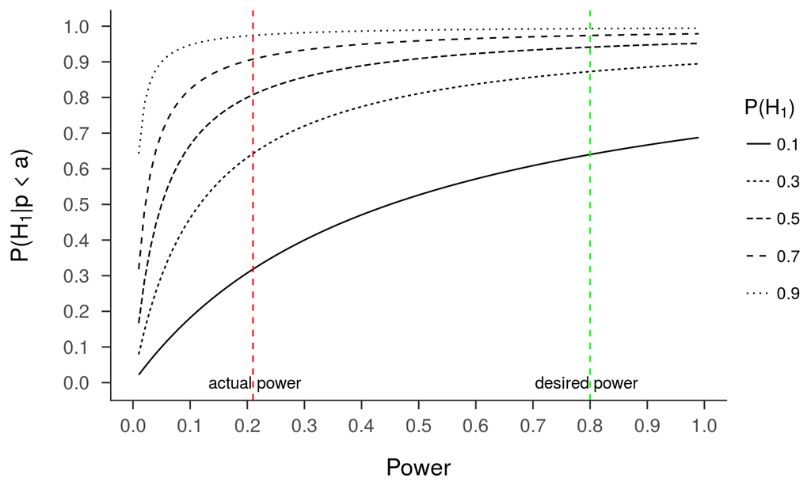

## Why most published research is false

[Demo](http://shinyapps.org/apps/PPV/)

## Sequential analysis

- I might have testicular cancer, so I'll go to the doctor to do a test

\[ \begin{split} H_0 &: \text{no cancer} \\ H_1 &: \text{cancer} \\ \end{split} \]

- assuming the following (data for the base rate from [here](https://seer.cancer.gov/statfacts/html/testis.html))

\[ \begin{split} P(H_1) &= .0016 \\ P(\text{pos.}|H_0) &= .1 \\ P(\text{pos.}|H_1) &= .999 \end{split} \] - What is the probability that I have cancer, given that I test positively?

## Sequential analysis

- We can plug it into Bayes' rule

- Only about 1.5%
- Doing another test, I test positively again. Oh man!
- What is the probability that I have cancer now?

## Sequential analysis

- I can — and should! — use the posterior of the first test as the prior for the second

## Probability theory

- It is a branch of mathematics based on set theory, and as such uncontroversial
- However, there are different interpretations of probability
  - *Frequentist view:* Probability is long-running frequency
  - *Bayesian view:* Probability as degree of belief
- What is the probability that Angela Merkel wins the German election?
- What is the probability of a global temperature rise of 2°C in the 30 years?

## Frequentist interpretation

"The rational concept of probability, which is the only basis of probability calculus, applies only to problems in which either the same event repeats itself again and again … [In] order to apply the theory of probability we must have a practically unlimited sequence of observations."

- Richard von Mises (quoted in Jackman, 2009, p. 5)

## Bayesian interpretation

The abandonment of superstitious beliefs about…Fairies and Witches was an essential step along the road to scientific thinking. Probability, too, if regarded as something endowed with some kind of objective existence, is not less a misleading misconception, an illusory attempt to exteriorize or materialize our true probabilistic beliefs. In investigating the reasonableness of our own modes of thought and behaviour under uncertainty, all we require, and all that we are reasonably entitled to, is consistency among these beliefs, and their reasonable relation to any kind of relevant objective data (‘relevant’ in as much as subjectively deemed to be so). This is Probability Theory (de Finetti 1974, 1975, x).

- Bruno de Finetti (quoted in Jackman, 2009, p. 7)

## Statistical models

## Statistical models

- Say I have a set of \(n = 100\) observations \(d = \{x_1, x_2, x_3, \ldots, x_n\}\)
- You ask me about the data; what can I tell you?

```r
x
```

```
##   [1] 107.97829  97.69310 105.68723  91.57817 100.68255  99.36588 113.81083
##   [8] 104.03224  87.80916  89.35512 110.42069  85.15186  97.48300 100.40710
##  [15]  99.52343 108.13351  76.99894  94.06699  97.02159  93.92357 121.06758
##  [22] 104.91280  92.48396 108.75160 104.85715 102.44135 107.42267 115.40291
##  [29] 105.29429 111.19024 100.96793  83.76809 101.20973 106.53400 103.20483
##  [36]  96.63230 112.29554  85.09677 119.74183  96.44044 110.73340 100.41942
##  [43] 105.36852 104.88455 106.27562  89.70382 104.66260  94.95458  89.90731
##  [50] 118.17459  90.85233 112.99377 103.12626  96.37302  92.45636  99.70174
##  [57]  97.29787  95.07651 116.58248  87.37510  89.91494  99.70467  97.43632
##  [64] 107.66106  85.73984 110.95736 101.22271 106.39446 104.21625  87.33096
##  [71]  93.35681 102.30501  97.05229  98.09652  96.22863 109.15487  94.86212
##  [78] 102.97085 106.76618 109.77560  81.26005  92.04866 101.85651  99.68925
##  [85] 101.97910  78.06927 114.79401  96.77466  98.15235 103.90206  95.19197
##  [92]  99.48015  98.22895  80.30618 101.59158  90.52129 105.40732  81.46523
##  [99]  97.32792 116.16882
```

## Statistical models

- Introduce a statistical model to reduce complexity
- A statistical model describes the relationship of one or more **latent parameters** to the observations

\[ f(x; \mu, \sigma) = \frac{1}{\sqrt{2\pi\sigma^2}} \exp \big (-\frac{1}{2\sigma} (x - \mu)^2 \big) \]

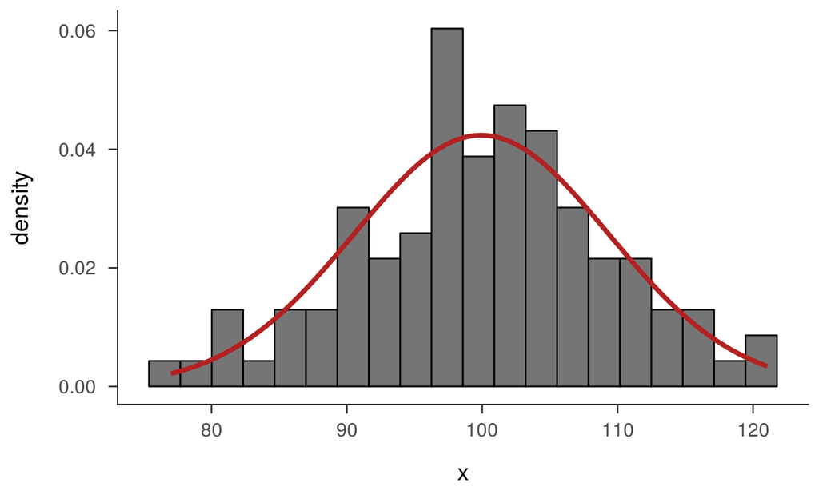

## Statistical models

- I used a normal distribution for the data
- Now I can describe the data with just two numbers — the mean \(\mu\) and the standard deviation \(\sigma\)

```r
c(mean(x), sd(x))
```

```
## [1] 99.931219  9.413697
```

- But there are other possible statistical models I could use!

## Statistical models

- Statistical models need not be appropriate; in fact, they can be horribly misspecified!

\[ f(x; a, b) = \frac{1}{b - a} \]

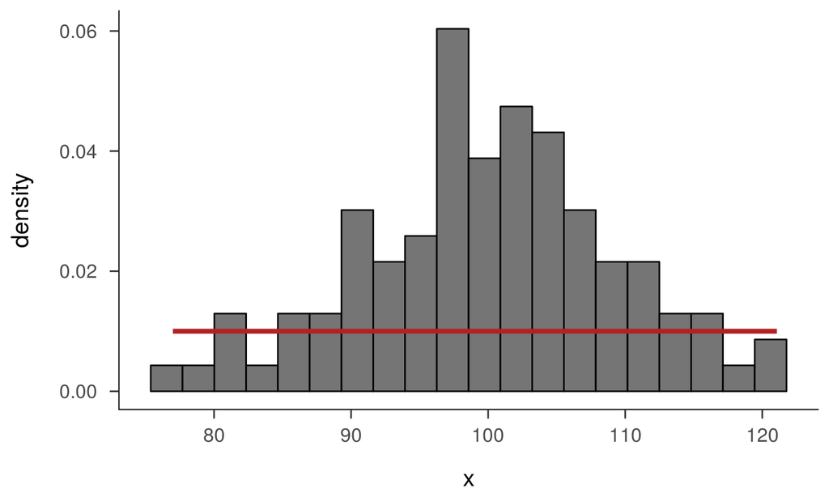

## Statistical models: Notation

- Statistical models can be specified as **directed acyclic graphs**

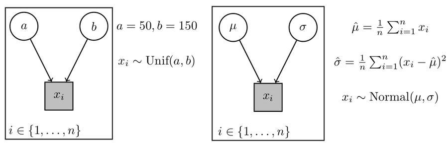

## Bread and butter

- A slice of bread with butter falls on the floor
- It can either land with butter up (**0**) or butter down (**1**)
- Questions
  - What is the propensity of the bread to fall on the floor with the butter side down?
  - How do I describe the data-generating process? Any suggestions?

## Bread and butter

- First, note that the outcome is binary. The random variable describing the outcome is \(X = \{0, 1\}\)
- A good, tried suggestion would be the following statistical model

\[ \begin{align*} f(x; \theta) &= \theta^x (1 - \theta)^{1 - x} \\[2ex] &= \begin{cases} \theta & \text{if } x = 1 \\ 1 - \theta & \text{otherwise} \end{cases} \end{align*} \] - where \(\theta\) is the latent parameter whose value influences the outcome

## Statistical models: Bread and butter

- How do I describe \(n\) events?
- I make a very contentious assumption: **independent and identically distributed samples**
- Assume I have \(n = 20\) data points \(d = \{x_1, x_2, x_3, \ldots, x_n\}\)

## Statistical models: Bread and butter

\[ \begin{align*} f(x; \theta) &\stackrel{\text{i.i.d.}}{=} f(x_1; \theta) \cdot f(x_2; \theta) \cdot \ldots \cdot f(x_n; \theta) \\ &= \prod^n_{i=1} f(x_i; \theta) \\ &= \prod^n_{i=1} \theta^{x_i} (1 - \theta)^{1 - x_i} \\ &= \theta^{\sum^n_{i = 1} x_i} (1 - \theta)^{\sum^n_{i = 1} 1 - x_i} \end{align*} \]

- We don't care about the outcome order; e.g., whether \(x = \{1, 0 \}\) or \(x = \{0, 1\}\)

## Binomial likelihood

- Neglecting the order, we only model the number of falls with butter on the floor
- Introducing a new random variable \(Y\)

\[ Y = \sum_{i=1}^n x_i \]

- and noting that there are

\[ n\cdot(n - 1)\cdot \ldots \cdot (n - y + 1) = \frac{n!}{y!(n - y)!} = {n \choose y} \]

- possible ways of obtaining \(Y = y\) successes yields the **Binomial likelihood**

## Binomial likelihood

\[ \begin{align*} f(x; \theta) &\stackrel{\text{i.i.d.}}{=} f(x_1; \theta) \cdot f(x_2; \theta) \cdot \ldots \cdot f(x_n; \theta) \\ &= \prod^n_{i=1} f(x_i; \theta) \\ &= \prod^n_{i=1} \theta^{x_i} (1 - \theta)^{1 - x_i} \\ &= \theta^{\sum^n_{i = 1} x_i} (1 - \theta)^{\sum^n_{i = 1} 1 - x_i} \\[4ex] f(y; \theta, n) &= {n \choose y} \theta^{\sum^n_{i = 1} x_i} (1 - \theta)^{\sum^n_{i = 1} 1 - x_i} \hspace{3em} \text{Neglecting order} \\[1ex] &= {n \choose y} \theta^{y} (1 - \theta)^{n - y} \hspace{7em} \text{Introducing } Y = \sum^n_{i=1} x_i \\ \end{align*} \]

## Binomial likelihood

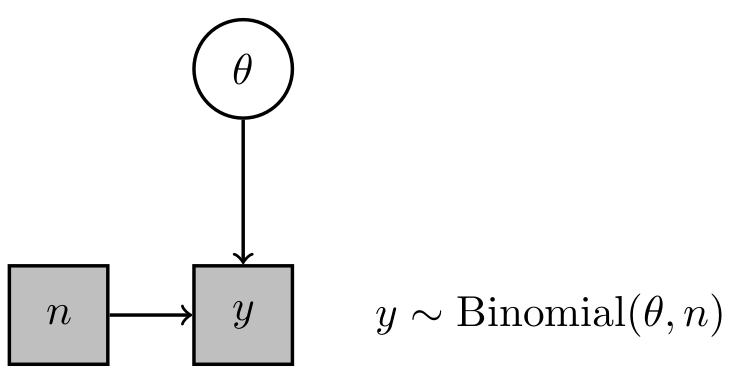

## Binomial likelihood

- \(\theta\) describes how the data will turn out
- In other words: the likelihood is a distribution for the data

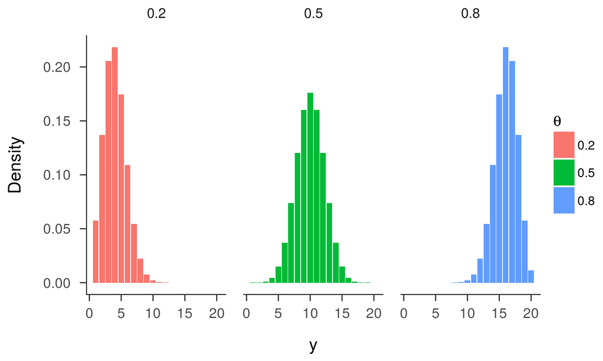

## Binomial likelihood

Shiny applications not supported in static R Markdown documents

## Fundamental theorems

## Two corners of (frequentist) statistics

- Law of the large number \[ \begin{split} \overline{X}_n &= \frac{1}{n}(X_1 + \ldots + X_n) \\[2ex] \overline{X}_n &\rightarrow \mu \qquad \text{for} \qquad n \rightarrow \infty \end{split} \]
- Computing the mean of a random variable \(X\)

\[ \begin{split} \mathbb{E}[X] &= \int x \cdot P(x) \mathrm{d}x \\ &= \lim_{N \to \infty} \frac{1}{N} \sum_{x_i \sim P}^{N} x_i \end{split} \]

## Law of large numbers

- Computing the mean of rolling a six-sided die
- The accuracy of the empirical statistic (the mean) increases with sample size

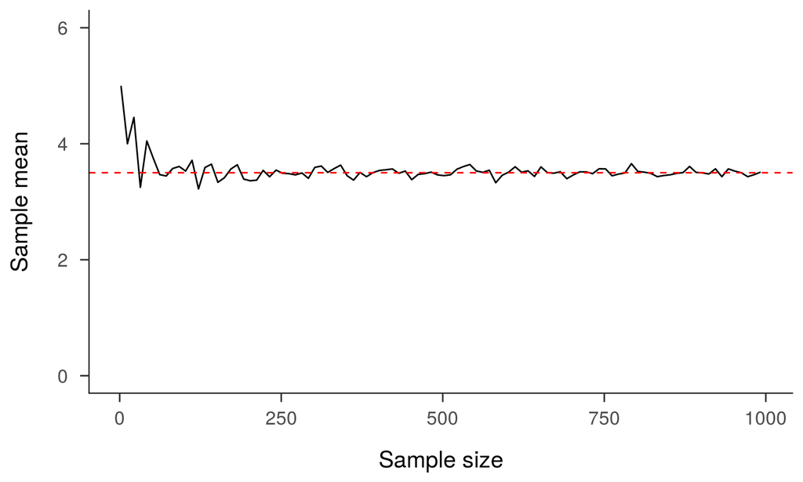

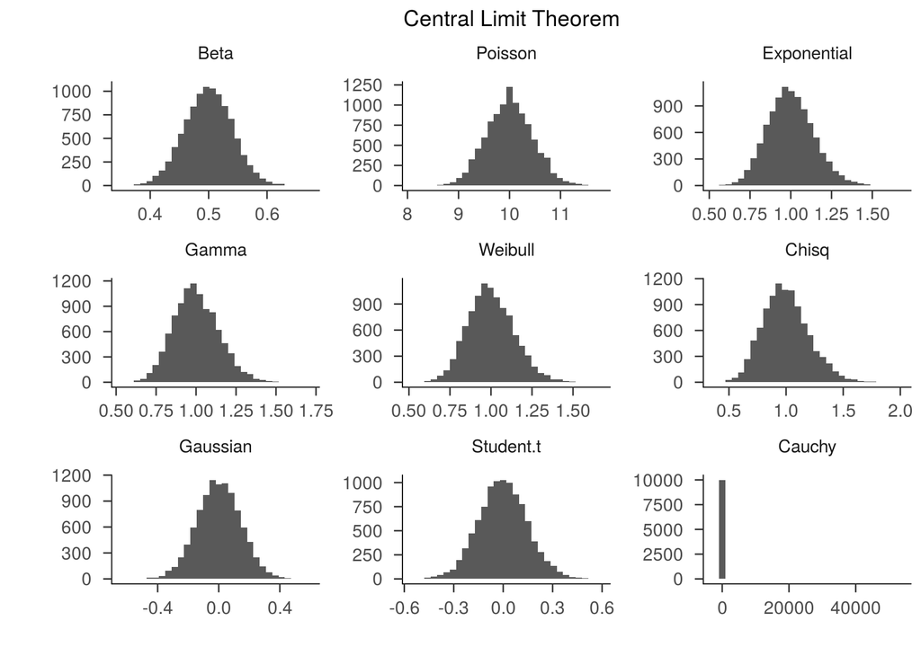

## Statistical models cont'd

## Bread and butter

- I want to learn \(\theta\) — what are good values for it, given the data below?

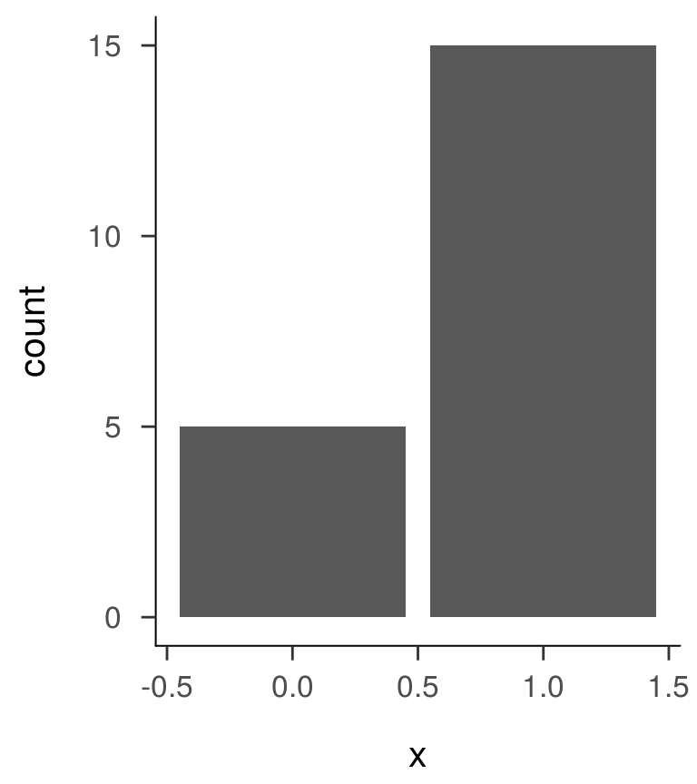

## Bread and butter

- **How likely is the data given certain parameter values?**
- Let's compare \(\theta = .5\) and \(\theta = .75\) on our flipping data (\(y = 15, n = 20\))

## Bread and butter

- Let's plot the likelihood of the data as a function of \(\theta\)

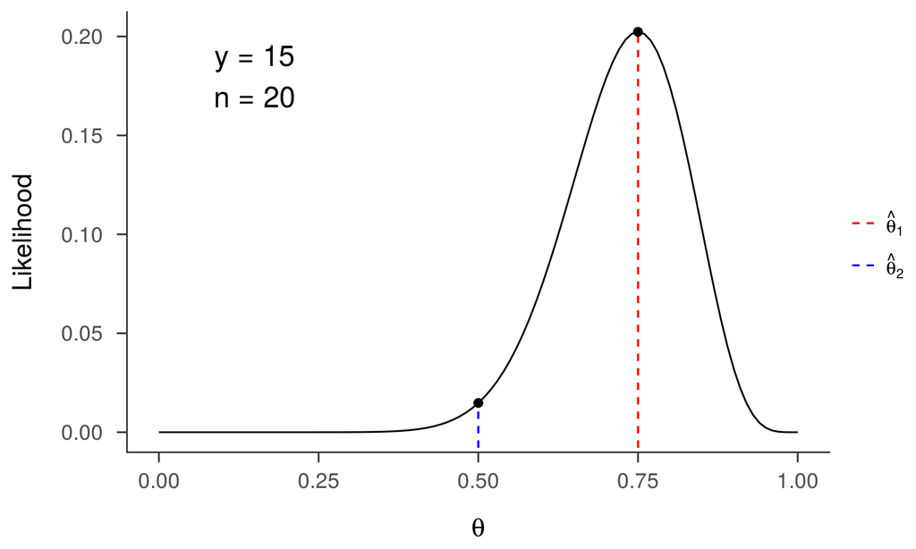

## Likelihood ratios

Shiny applications not supported in static R Markdown documents

## Classical and Bayesian statistics

## A neutral Bird's eye view

| Ronald Fisher | Neyman-Pearson | Bayesian |
| --- | --- | --- |
| Probability as long-run frequency | Probability as long-run frequency | Probability as degree of belief |
| *p*-value | *p*-value | Bayes factors |
| \(\alpha\) | \(\alpha, \beta\) | - |
| Parameters are fixed | Parameters are fixed | Parameters are random |
| Pre-data | Pre-data | Post-data |
| Epistemic approach | Behavioural approach | Epistemic approach |
| Various estimators | Various estimators | Bayes' rule |
| - | Confidence Intervals | Credible intervals |
| Point estimates | Point estimates | Posterior distributions |

## A polemic Bird's eye view

| Classical Statistics | Bayesian Statistics |
| --- | --- |
| Ad-hoc | Axiomatic |
| Incoherent | Coherent |
| Paradoxical | Intuitive |
| Irrational | Rational |
| Ugly | Pretty |
| Irrelevant | Relevant |
| what's taught | what's not taught |

borrowed from [EJ Wagenmakers](https://docs.google.com/file/d/0B-Ww24m3ZkEyMEpudlVsX3pRVzA/edit)

## Practical example

- **Data example**
  - We observe \(n = 20\) pieces of bread with butter falling down
  - \(y = 15\) land on the floor with the butter down
  - Questions
    - Estimation: What are likely values for \(\theta\)?
    - Testing: Is bread with butter more likely to fall butter down?
    - Prediction: How likely is the next piece to fall butter down?

| Problem | Classical statistics | Bayesian statistics |
| --- | --- | --- |
| Estimation | Maximum Likelihood, CIs | Posterior distribution (**Bayes' rule**) |
| Testing | *p*-value | Bayes factor (**Bayes' rule**) |
| Prediction | Plug-in Estimate | Account for uncertainty using **Bayes' rule** |

## Classical statistics

## Bread and Butter: Estimation

- Many different estimators, but most popluar is maximum likelihood estimate; \(\hat{\theta} = \frac{y}{n}\)

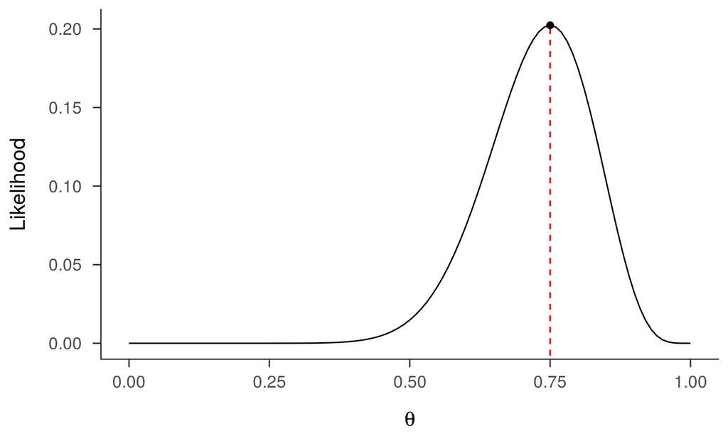

## Bread and Butter: Estimation

- The main approach of classical statistics in two sentences

"We assume that we sample repeatedly from a population; each time we compute an estimate based on the sample. The distribution of these estimates — the sampling distribution — gives the precision of the specific estimate."

- In other words

"We conduct an experiment. We then assume that we conduct exactly the same experiment over and over again. For each such experiment, we compute a statistic (say the mean). Plotting these statistics yields the sampling distribution (of the mean)."

## Bread and Butter: Estimation

```r
conduct_experiment <- function(y, n) rbinom(n, 1, prob = y / n)
replicate(10, conduct_experiment(y, n))
```

```
##       [,1] [,2] [,3] [,4] [,5] [,6] [,7] [,8] [,9] [,10]
##  [1,]    0    0    1    0    1    1    1    1    1     1
##  [2,]    1    1    0    1    1    1    1    1    1     1
##  [3,]    1    1    1    1    0    1    1    1    1     1
##  [4,]    1    1    0    1    1    1    1    0    1     0
##  [5,]    1    1    1    1    1    1    1    1    1     1
##  [6,]    1    0    1    1    1    1    1    1    1     1
##  [7,]    1    0    1    1    1    0    1    1    1     1
##  [8,]    0    1    1    1    1    1    1    1    1     0
##  [9,]    1    1    1    1    1    1    1    1    1     0
## [10,]    1    1    1    1    1    0    1    1    1     1
## [11,]    0    1    1    1    1    0    0    1    1     1
## [12,]    1    1    0    0    1    1    1    1    1     0
## [13,]    1    0    0    1    1    1    1    0    1     0
## [14,]    1    1    1    1    1    1    1    0    0     0
## [15,]    1    0    1    1    1    1    1    1    1     1
## [16,]    1    1    0    1    1    1    1    0    1     1
## [17,]    1    1    0    1    0    1    0    1    1     1
## [18,]    1    1    0    1    1    1    0    1    1     1
## [19,]    1    0    1    0    1    1    0    1    0     1
## [20,]    1    1    0    1    0    0    1    0    0     1
```

## Bread and Butter: Estimation

```r
sampling_distribution <- apply(replicate(10000, conduct_experiment(y, n)), 2, mean)
```

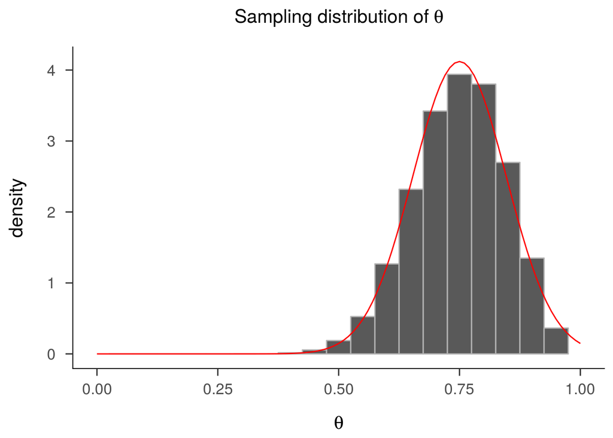

## Confidence intervals

```r
binom::binom.confint(y, n)
```

```
##           method  x  n      mean     lower     upper
## 1  agresti-coull 15 20 0.7500000 0.5275246 0.8919128
## 2     asymptotic 15 20 0.7500000 0.5602273 0.9397727
## 3          bayes 15 20 0.7380952 0.5534553 0.9100745
## 4        cloglog 15 20 0.7500000 0.4999439 0.8874709
## 5          exact 15 20 0.7500000 0.5089541 0.9134285
## 6          logit 15 20 0.7500000 0.5216093 0.8919420
## 7         probit 15 20 0.7500000 0.5308078 0.8982564
## 8        profile 15 20 0.7500000 0.5375302 0.9020982
## 9            lrt 15 20 0.7500000 0.5375491 0.9021575
## 10     prop.test 15 20 0.7500000 0.5058845 0.9040674
## 11        wilson 15 20 0.7500000 0.5312991 0.8881383
```

## Confidence intervals

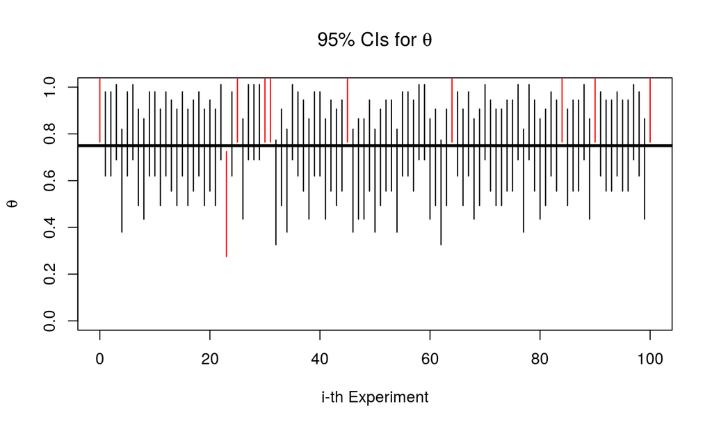

## Confidence intervals

[Demo](http://rpsychologist.com/d3/CI/)

## \(p\)-values

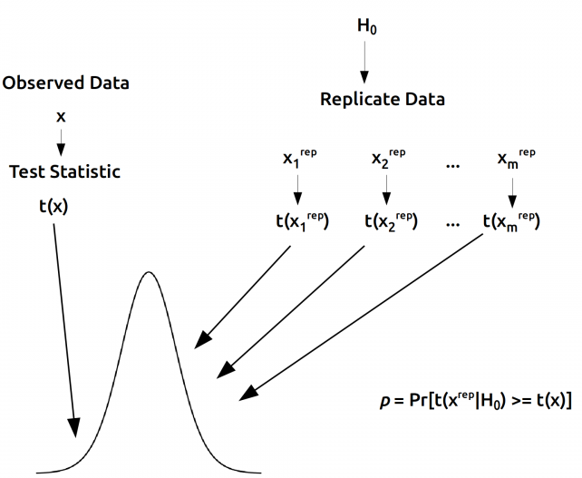

## \(p\)-values

- We replicate data under the assumption that \(H_0\) is true, i.e, \(\theta = .5\)

```r
conduct_experiment_h0 <- function(n) sum(rbinom(n, 1, prob = .5))
yrep <- replicate(5000, conduct_experiment_h0(n))

head(yrep, 10) # peak at some experiment outcomes
```

```
##  [1] 10 13  9 13 10 10  9 13  9  7
```

- Then we compute the probability that these data are at least as extreme as the one we observed

```r
mean(yrep >= y) * 2
```

```
## [1] 0.042
```

## \(p\)-values

```r
binom.test(y, n)
```

```
##
##  Exact binomial test
##
## data:  y and n
## number of successes = 15, number of trials = 20, p-value = 0.04139
## alternative hypothesis: true probability of success is not equal to 0.5
## 95 percent confidence interval:
##  0.5089541 0.9134285
## sample estimates:
## probability of success
##                   0.75
```

## Bayesian statistics

## Bayesian estimation

- Recap of the murder mistery
- **Joint probability**

\[ P(\text{Axe}, \text{Suicide}) = \frac{1}{12} \] - **Marginal probability**

\[ \begin{split} P(\text{Suicide}) &= \frac{1}{3} \\[1ex] &= P(\text{Axe}, \text{Suicide}) + P(\text{Knife}, \text{Suicide}) + P(\text{Pistol}, \text{Suicide}) \\[1ex] &= \frac{1}{12} + \frac{1}{12} + \frac{2}{12} \\[2ex] &\Rightarrow \sum_{W}^{3} P(W, \text{Suicide}) \qquad \text{Sum rule} \end{split} \]

## Bayesian estimation

|  | \(\text{He killed himself}\) | \(\text{She killed him}\) | \(\text{Butler killed him}\) |
| --- | --- | --- | --- |
| \(\text{Used axe}\) | \(\frac{1}{12}\) | \(\frac{1}{12}\) | \(\frac{2}{12}\) |
| \(\text{Used knife}\) | \(\frac{1}{12}\) | \(\frac{3}{12}\) | \(\frac{1}{12}\) |
| \(\text{Used pistol}\) | \(\frac{2}{12}\) | \(0\) | \(\frac{1}{12}\) |
| \(\text{Sum (Prior)}\) | \(\frac{1}{3}\) | \(\frac{1}{3}\) | \(\frac{1}{3}\) |

## Bayesian estimation

- Recap of why most published research is wrong
- What is the probability that my hypothesis is true, given that I have observed \(p < \alpha\)?

\[ \begin{split} P(H_1|p < \alpha) &= \frac{P(p < \alpha|H_1)P(H_1)}{P(p < \alpha)} &= \frac{P(p < \alpha|H_1)P(H_1)}{P(p < \alpha|H_1)P(H_1) + P(p < \alpha|H_0)P(H_0)} \end{split} \]

## Bayesian estimation

- Uses Bayes' rule \[ \underbrace{p(\theta|y)}_{\text{Posterior}} = \frac{\overbrace{f(y; \theta)}^{\text{Likelihood}}\overbrace{p(\theta)}^{\text{Prior}}}{\underbrace{p(y)}_{\text{Marginal Likelihood}}} \]
- where, applying the sum rule of probability

\[ p(y) = \int_{\theta} f(y; \theta)p(\theta) \mathrm{d}\theta \]

## Beta distributions

\[ p(\theta|\alpha, \beta) = \frac{1}{\text{Beta}(\alpha, \beta)} \theta^{\alpha - 1}(1 - \theta)^{\beta - 1} \]

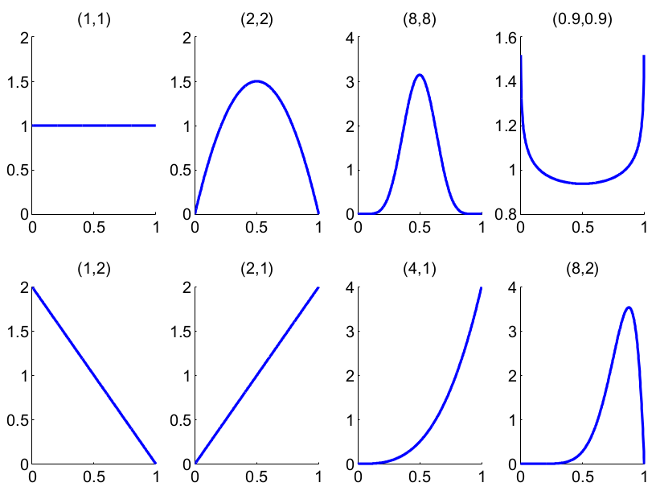

## Beta distributions and betting

Shiny applications not supported in static R Markdown documents

## Bayesian graphical model

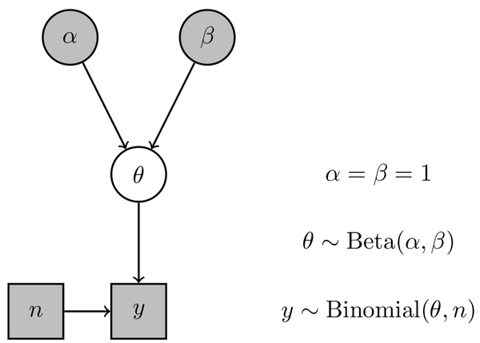

## Bayesian estimation

\[ \begin{split} p(\theta|y) &= \frac{f(y; \theta)p(\theta)}{\int_{\theta}f(y; \theta)p(\theta)\mathrm{d}\theta} \\[1ex] p(\theta|y) &= \frac{{n \choose y} \theta^y (1 - \theta)^{n - y} \frac{1}{\mathcal{B}(a, b)} \theta^{\alpha - 1}(1 - \theta)^{\beta - 1}}{\int_{\theta}{n \choose y} \theta^y (1 - \theta)^{n - y} \frac{1}{\mathcal{B}(a, b)} \theta^{\alpha - 1}(1 - \theta)^{\beta - 1}\mathrm{d}\theta} \end{split} \] - with some rearranging, we find that

\[ p(\theta|y) = \frac{1}{\text{Beta}(y + \alpha, n - y + \beta)} \theta^{y + \alpha - 1}(1 - \theta)^{n - y + \beta - 1} \]

## Bayesian updating

Shiny applications not supported in static R Markdown documents

## Bayesian model comparison

- In classical statistics, we test

\[ H_0: \theta = .5 \\ H_1: \theta \neq .5 \\ \]

- but the model which instantiates \(H_1\) makes no predictions whatsoever!
- We could use likelihoods to compare the hypotheses, such as

\[ \begin{split} H_0&: \theta = .5 \\ H_1&: \theta = .75 \end{split} \]

- but this is too demanding; why .75? Why not .80? Or .30?

## Bayesian model comparison

- We are uncertain about alternative values for \(\theta\)
- Bayes solution: quantify our uncertainty with a prior distribution

\[ \begin{split} H_0&: \theta = .5 \\ H_1&: \theta \sim \mathcal{Beta}(\alpha, \beta) \end{split} \]

- Now both models make predictions!
- Bayesian model comparison pits the predictive accuracy of two models against each other \[ \begin{split} p(y|M_0) &= \int_{\theta} p(y, \theta|M_0)\mathrm{d}\theta \\[1ex] &= \int_{\theta} p(y|M_0, \theta)p(\theta|M_0)\mathrm{d}\theta \\[1ex] &= f(y|M_0, \theta = .5) \\[2ex] &= {20 \choose 15} .50^{15} (1 - .50)^{20 - 15} \approx 0.0147 \end{split} \]

## Bayesian model comparison

- For \(M_1\), it's a bit more complicated

\[ \begin{split} p(y|M_1) &= \int_{\theta} p(y, \theta|M_1)\mathrm{d}\theta \\[1ex] &= \int_{\theta} p(y|M_1, \theta)p(\theta|M_1)\mathrm{d}\theta \\[1ex] &= \int_{\theta} {20 \choose 15} \theta^{15} (1 - \theta)^{20 - 15} \frac{1}{\text{Beta}(a, b)}\theta^{\alpha - 1}(1 - \theta)^{\beta - 1}\mathrm{d}\theta \\[1ex] &\approx \frac{1}{N} \sum_{\theta \sim \mathcal{Beta}(\alpha, \beta)}^N {20 \choose 15} \theta^{15} (1 - \theta)^{20 - 15} \hspace{3em} \text{Monte Carlo integration} \\[1ex] &\approx 0.047 \end{split} \]

## Bayesian model comparison

- How do we update our beliefs across models? \[ \begin{split} \underbrace{\frac{p(M_0 \mid y)}{p(M_1 \mid y)}}_{\text{posterior odds}} &= \underbrace{\frac{p(y \mid M_0)}{p(y \mid M_1)}}_{\text{Bayes factor}} \, \cdot \underbrace{\frac{p(M_0)}{p(M_1)}}_{\text{prior odds}} \\[1ex] \frac{p(M_0|y)}{p(M_1|y)} &= \frac{.0147}{.0477} \cdot \frac{1/2}{1/2} \approx .31 \end{split} \]

[figure not shown]

## Bayes factor

- is the non-plus-ultra of model comparison
  - complex models can predict many data patterns
  - thus spread out their prior probability
  - this gets factored into the marginal likelihood and decreases it
  - instantiates an **automatic Ockham's razor**
- looks at the functional form of the model, compared to
  - \(AIC = -2 \log p(\textbf{y}|\hat \theta) + 2\cdot k\)
  - \(BIC = -2 \log p(\textbf{y}|\hat \theta) + \log n \cdot k\)
- which penalize just based on the number of parameters \(k\)

## Thermometer of evidence

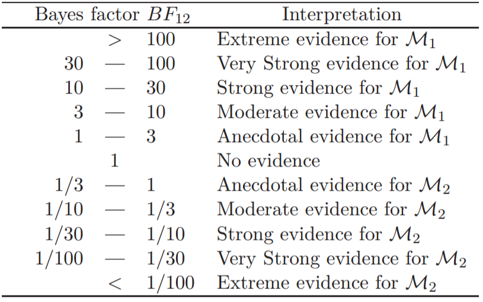

## Lindley's Paradox

```r
k <- 49581
N <- 98451
```

\[ H_0: \theta = .5 \\ H_1: \theta \neq .5 \]

**\(p\)-value**

```
## [1] 0.02364686
```

\[ \begin{split} H_0&: \theta = .5 \\ H_1&: \theta \sim \mathcal{Beta}(1, 1) \end{split} \]

**\(BF_{01}\)**

```
## [1] 19.21139
```

## Bayesian prediction

- What is the probability that the next slice of bread will fall butter down?

## Bayesian prediction

- The prior regularizes and avoids embarrassing inference and prediction
- For \(y = 3, n = 3\) the maximum likelihood estimate is \(\theta_{\text{MLE}} = 1\) and predicts \(p(y' = 1|y)\) with 100% certainty
- This has consequences for a host of more complicated models and is termed *overfitting*
- Bayesian prediction safeguards against this
- Classical methods achieving the same thing are called **penalized likelihood** methods, such as
  - the lasso (which corresponds to Bayesian regression with Laplace priors)
  - ridge regression (which corresponds to Bayesian regression with Gaussian priors)

## Some applications

## Simulator sickness and age

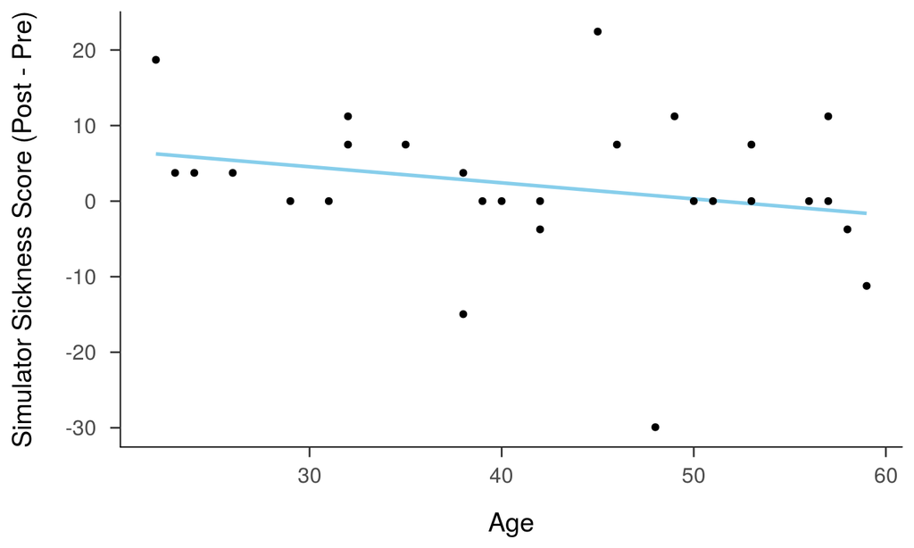

## Simulator sickness and age

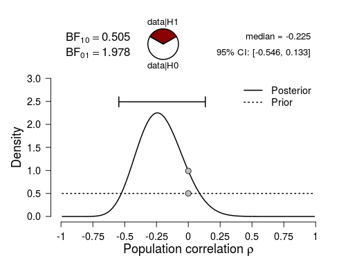

- What did we actually do? What is our statistical model?

## Simulator sickness and age

- Propose as statistical model a multivariate Gaussian distribution for the standardized variable \(X = [x_1, x_2]\)

\[ f(x|\Sigma) = \frac{1}{\sqrt{2\pi}} |\Sigma|^{-1} \exp \big (\frac{1}{2}x^T\Sigma^{-1}x \big) \]

```r
X <- ss_dat[, c('age', 'diff_ssq')]
Xs <- scale(X)
head(cbind(X, Xs))
```

```
##   age diff_ssq        age   diff_ssq
## 1  57     0.00  1.2997928 -0.2014369
## 2  53     0.00  0.9540047 -0.2014369
## 3  53     7.48  0.9540047  0.5505942
## 4  32    11.22 -0.8613828  0.9266097
## 5  32     7.48 -0.8613828  0.5505942
## 6  39     0.00 -0.2562537 -0.2014369
```

## Bivariate Gaussian Distribution

Shiny applications not supported in static R Markdown documents

## Simulator sickness and age

- The shape of the multivariate Gaussian is determined by the correlation matrix

\[ \Sigma = \begin{pmatrix} 1 & \rho \\ \rho & 1 \end{pmatrix} \] - We want to compare

\[ \begin{split} H_0&: \rho = 0 \\ H_1&: \rho \sim \text{Beta}(1, 1) \end{split} \]

- For \(M_0\), this is just the simple likelihood for \(\rho = 0\)

\[ \begin{split} p(d|M_0) &= \frac{1}{\sqrt{2\pi}} \exp \big (-\frac{1}{2}x^T\begin{pmatrix} 1 & 0 \\ 0 & 1 \end{pmatrix} ^{-1}x \big) \\[1ex] &\approx 8.414\mathrm{e}^{-35} \end{split} \]

## Simulator sickness and age

- Again, for \(M_1\) it's a bit more complicated as it involves integration over \(\rho\)

\[ \begin{split} p(d|M_1) &= \int_{\rho} p(d, \rho|M_1)\mathrm{d}\rho \\[1ex] &= \int_{\rho} p(d|M_1, \rho)p(\rho|M_1)\mathrm{d}\rho \\[1ex] &= \int_{\rho} f(x;\Sigma)\text{Unif}(-1, 1)\mathrm{d}\rho \\[1ex] &= \int_{\rho} \frac{1}{\sqrt{2\pi}} |\Sigma|^{-1} \exp \big (\frac{1}{2}x^T\Sigma^{-1}x \big) \frac{1}{2} \mathrm{d}\rho \\[1ex] &\approx \frac{1}{N} \sum_{\rho_i \sim \text{Unif}(-1, 1)} ^N \frac{1}{\sqrt{2\pi}} |\Sigma|^{-1} \exp \big (\frac{1}{2}x^T\begin{pmatrix} 1 & \rho_i \\ \rho_i & 1 \end{pmatrix}^{-1}x \big) \\[1ex] &\approx 4.278\mathrm{e}^{-35} \end{split} \]

## Simulator sickness and age

\[ \text{BF}_{01} = \frac{8.414\mathrm{e}^{-35}}{4.278\mathrm{e}^{-35}} = 1.966 \]

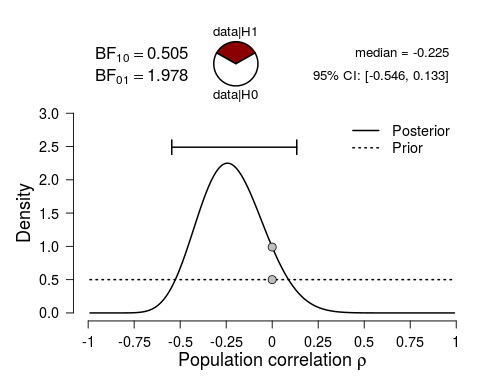

## Simulator sickness and age

- The model I suggested is actually wrong (just look at the population distribution of age)
- Moreover, Pearson correlation does not require Gaussian random variables
- It only requires continuous random variables

## Harry Potter Sorting Hat Quiz

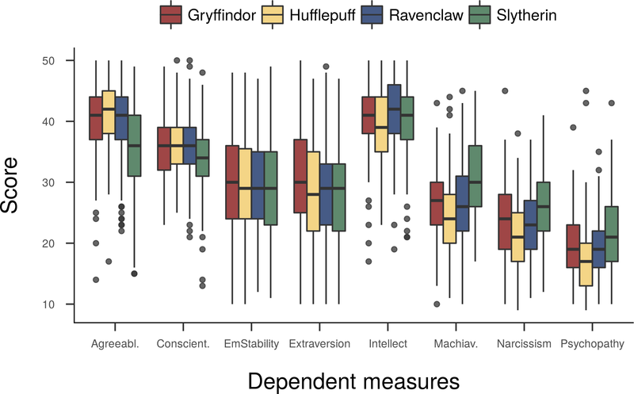

## Harry Potter Sorting Hat Quiz

- Previous research has used a t-test comparing, say
  - Mean extraversion of Gryffindor with Mean extraversion of Ravenclaw, Hufflepuff, Slytherin
  - This is not what we want!
- Using Bayesian inference, we can compare models with order-constraints on the mean

\[ \begin{split} M_0 &: \mu_{\text{G}} = \mu_{\text{S}} = \mu_{\text{R}} = \mu_{\text{H}} \\ M_f &: \mu_{\text{G}}, \, \mu_{\text{S}} , \, \mu_{\text{R}} , \, \mu_{\text{H}} \\ M_r &: \mu_{\text{G}} > (\mu_{\text{S}} , \, \mu_{\text{R}} , \, \mu_{\text{H}}) \end{split} \]

## Markov chain Monte Carlo with People

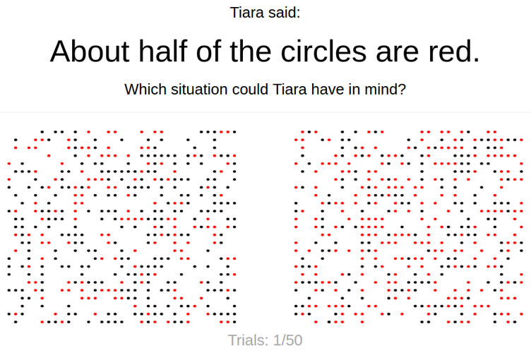

## Markov chain Monte Carlo with People

[Interactive Exploration of Data](https://fdabl.shinyapps.io/MCMCP/)

## Markov chain Monte Carlo with People

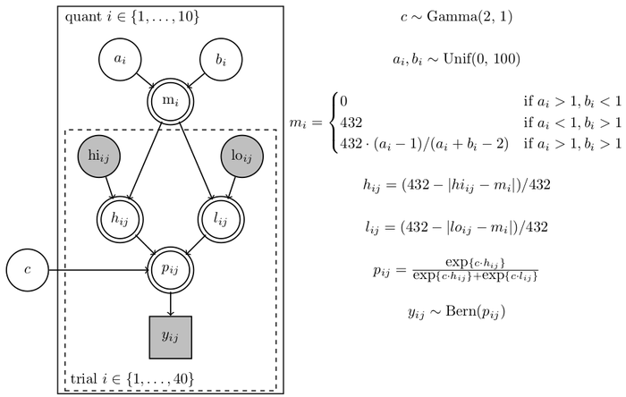

## Practicals with JASP

## JASP

- Undergoes rapid development in Eric-Jan Wagenmakers' lab in Amsterdam
- Has over 20 team members coming from psychology, statistics, and computer science
- Its aim is to supersede SPSS and provide Bayesian analysis to the world

## Current analyses

Table. *Analyses available in JASP 0.8.1.*

| Analysis | Bayesian | Frequentist |
| --- | --- | --- |
| Descriptives | - | - |
| One Sample T-Test | Yes | Yes |
| Paired Samples T-Test | Yes | Yes |
| Independent Samples T-Test | Yes | Yes |
| ANOVA | Yes | Yes |
| ANCOVA | Yes | Yes |
| Repeated Measures ANOVA | Yes | Yes |
| Linear Regression | Yes | Yes |
| Correlation | Yes | Yes |

## Current analyses

Table. *Analyses available in JASP 0.8.1.*

| Analysis | Bayesian | Frequentist |
| --- | --- | --- |
| Binomial Test | Yes | Yes |
| Contingency Tables | Yes | Yes |
| Log-Linear Regression | Yes | Yes |
| Summary Stats | Yes | - |
| Reliability Analysis | Not yet | Yes |
| Principal Component Analysis | Not yet | Yes |
| Exploratory Factor Analysis | Not yet | Yes |
| Structural Equation Modeling | Not yet | Yes |

## Correlation in JASP

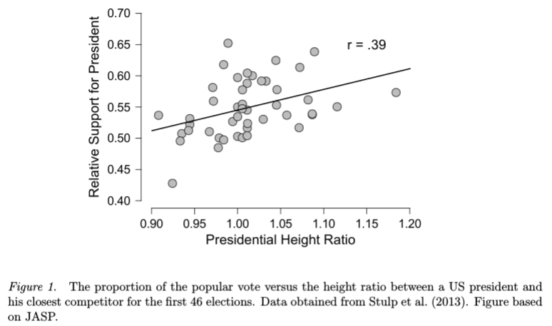